# What Are We Drinking? A Visual Story of Café Beverage Habits

## Every morning starts with a drink — but which one?

Every day, millions of people order a hot drink at a café. Over several weeks, I observed and logged **25 drink orders** across different times of day, recording the type, size, price, and exact timestamp of each order. This visual story explores three questions: which drinks cost the most, when do people buy them, and does size predict price?

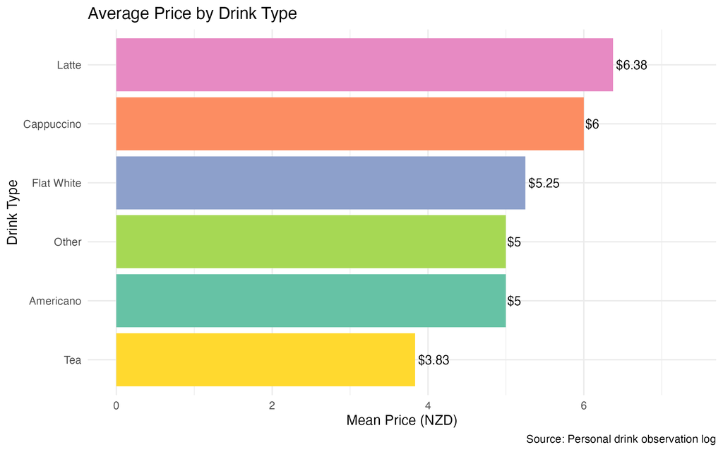

Bar chart showing average price in NZD by drink type. Latte has the highest mean price at around $6.50, while Tea is the cheapest at approximately $3.80.

## The morning rush is very real

Using the precise timestamps from each observation, I extracted the hour of each order to see when café activity peaks throughout the day.

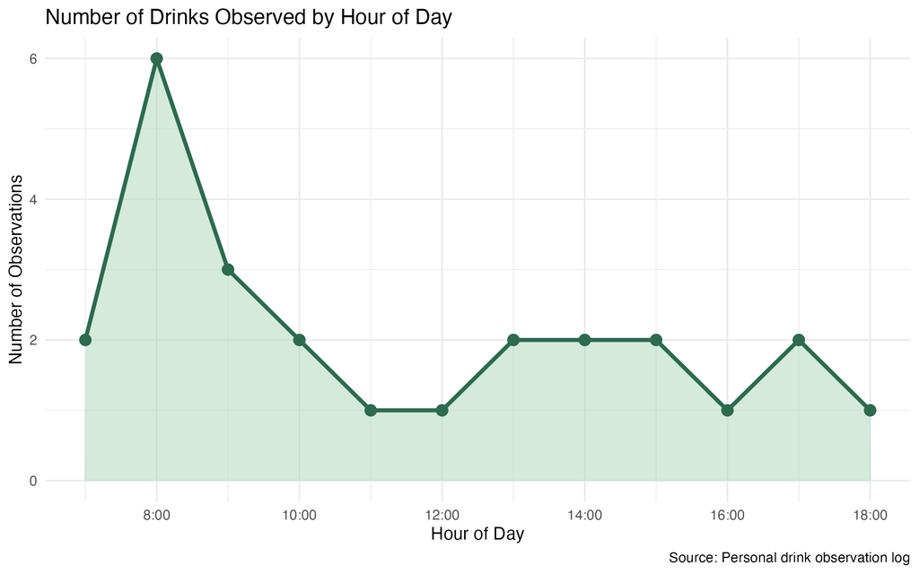

Area and line chart showing the number of drink observations by hour of day. A sharp peak occurs at 8:00 AM with 6 observations, followed by a gradual decline through the morning and low, steady activity from midday to 6 PM.